# Elección de compañero/a de piso: Unos meses después

Sabela Álvarez López

2024-05-10

# Post-Elección de compañero/a de piso

## ¿Quiénes éramos?

Éramos un chico, profe de inglés, y una chica, estudiante de máster, de 30 años, que buscábamos compañero/a de piso.

## ¿Qué buscábamos?

Se nos había quedado una habitación libre del piso y nos encontrábamos en plena búsqueda de compañero/a: un/a compi que le gustase hacer cosas en común, con quien echarnos una peli de vez en cuando, jugar a jueguitos de mesa y nos lo pasásemos bien viviendo en compañía. Además, considerábamos **imprescindible** que esta persona tuviese perro o gato, porque nos encantan los animales.

## ¿Qué pretendíamos?

Como somos unos apasionados de la informática y de la programación, decidimos hacer la búsqueda más amena (para nosotros, claro) haciendo unos simples análisis estadísticos en R, y unos cuantos grafiquitos… *¿qué puede salir mal?* Nos habían entrado **muchísimas** solicitudes y teníamos muchísimas dudas, por lo que decidimos que la “máquina” nos echara una mano.

## Los pasos que seguimos

### Paso 1

En primer lugar, instalamos los paquetes de excel, tidyverse, ggplot2, DT y kableExtra. Esto no se veía en la página web, porque lo ocultamos del Rmarkdown.

### Paso 2

En segundo lugar, creamos una tabla, que llamamos “Tabla_Companeros”, donde aunamos todos los datos que consideramos de interés para seleccionar al **compañero definitivo**: edad, ámbito de trabajo, pros, contras, y la escala en la que colocamos a ese posible compañero en función de esos parámetros.

```r
Tabla_Companeros<-read.xlsx(file="/Users/sabel/OneDrive/Escritorio/Master_UGR/Asignaturas/Ecoinformatica/proyectos_ecoinformatica/data/entrega_1_escala_companeros.xlsx", sheetName = "Escala")
Tabla_Companeros %>%
    kbl() %>%
    kable_paper("hover",
                full_width = F)
```

| Posible_companero | Edad | Ambito_trabajo | Pros | Contras | Escala |
| --- | --- | --- | --- | --- | --- |
| Clara | 30 | Trabajadora social | Amigable | Ninguno | 10 |
| Francisco | 41 | Investigador | Buen cocinero | Demasiado mayor | 3 |
| Javier | 36 | Informático | Tranquilo | Vida incompatible | 4 |
| Magdalena | 35 | Arquitecta | Simpatica | Vida incompatible | 6 |
| Antonio | 32 | Investigador | Responsable | Demasiado formal | 7 |
| Lucia | 22 | Estudiante | Maja | Demasiado joven | 5 |
| Eduardo | 23 | Estudiante | Ninguno | Vago | 1 |
| Alfredo | 24 | Camarero | Majo | Horario nocturno | 2 |
| Maria | 28 | Psicóloga | Responsable | Trabaja en remoto | 8 |
| Ana | 29 | Investigadora | Alegre | Ninguno | 9 |

### Paso 3

A partir de la tabla Tabla_Companeros, hicimos el gráfico “Grafica_Companeros”

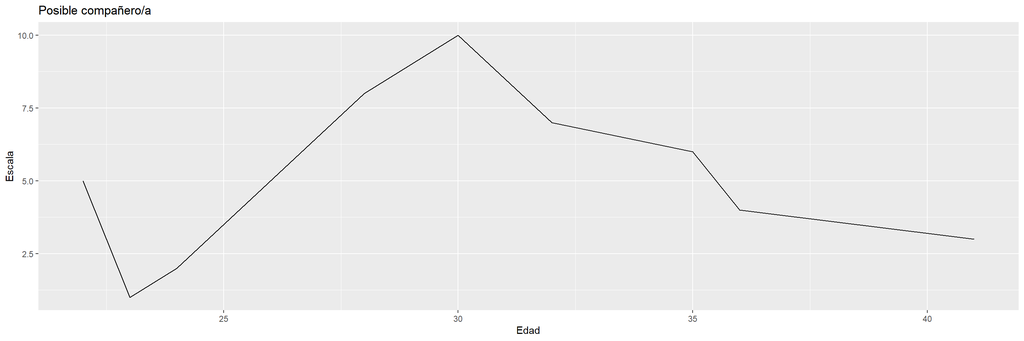

```r
Grafica_Companeros <- ggplot(data = Tabla_Companeros,
       mapping = aes(x=Edad,
                     y=Escala)) +
      geom_line() +
      labs(title="Posible compañero/a")
Grafica_Companeros
```

## ¿Qué sucedió?

La verdad es que, una vez visto la gráfica que creamos, nos dimos cuenta de que aquellas personas cuya edad se acercaba más a la nuestra, independientemente de los “pros” y “contras” que les hubiésemos asignado, alcanzaban una escala de puntuación de 10, o muy cercana.

De hecho, nos fijamos que a esas personas de 30 años, aproximadamente, les asignamos “pros”, pero prácticamente ninguna tenía “contra”, lo que nos hacía pensar también que, subjetivamente, nos convencían más y las veíamos con mejores ojos.

Por lo tanto, nos pusimos en contacto con Clara y con Ana.

Lamentablemente, Clara ya había encontrado piso :(

Entonces, nos quedamos con Ana. Al principio todo salió bien, pero al mes de vivir con nosotros tuvo que volver a mudarse y tuvimos que buscar compañero/a de nuevo. Fue una faena de excels, Rmarkdowns, gráficas y estadística, pero al final encontramos a un chico, Pepe, que venía con su perrito, y estamos encantados.